# Risk Factor Analysis

## Outcome Variable

**Outcome Variable:** haz

## Predictor Variables

**Intervention Variable:** impfloor

**Adjustment Set:**

- arm
- sex
- W_mage
- meducyrs
- feducyrs
- hhwealth_quart
- hfoodsec
- W_mhtcm
- W_nrooms
- W_nchldlt5
- W_parity
- impsan
- safeh20
- delta_W_mage
- delta_meducyrs
- delta_feducyrs
- delta_hhwealth_quart
- delta_hfoodsec
- delta_W_mhtcm
- delta_W_nrooms
- delta_W_nchldlt5
- delta_W_parity
- delta_impsan
- delta_safeh20

## Stratifying Variables

The analysis was stratified on these variable(s):

- agecat
- studyid
- country

## Data Summary

| agecat | studyid | country | impfloor | n_cell | n |
| --- | --- | --- | --- | --- | --- |
| Birth | ki0047075b-MAL-ED | BANGLADESH | 1 | 216 | 234 |
| Birth | ki0047075b-MAL-ED | BANGLADESH | 0 | 18 | 234 |
| Birth | ki0047075b-MAL-ED | BRAZIL | 1 | 172 | 174 |
| Birth | ki0047075b-MAL-ED | BRAZIL | 0 | 2 | 174 |
| Birth | ki0047075b-MAL-ED | INDIA | 1 | 181 | 191 |
| Birth | ki0047075b-MAL-ED | INDIA | 0 | 10 | 191 |
| Birth | ki0047075b-MAL-ED | NEPAL | 1 | 66 | 164 |
| Birth | ki0047075b-MAL-ED | NEPAL | 0 | 98 | 164 |
| Birth | ki0047075b-MAL-ED | PERU | 1 | 56 | 259 |
| Birth | ki0047075b-MAL-ED | PERU | 0 | 203 | 259 |
| Birth | ki0047075b-MAL-ED | SOUTH AFRICA | 1 | 197 | 218 |
| Birth | ki0047075b-MAL-ED | SOUTH AFRICA | 0 | 21 | 218 |
| Birth | ki0047075b-MAL-ED | TANZANIA, UNITED REPUBLIC OF | 1 | 8 | 117 |
| Birth | ki0047075b-MAL-ED | TANZANIA, UNITED REPUBLIC OF | 0 | 109 | 117 |
| Birth | ki1000108-CMC-V-BCS-2002 | INDIA | 1 | 71 | 71 |
| Birth | ki1000108-CMC-V-BCS-2002 | INDIA | 0 | 0 | 71 |
| Birth | ki1000108-IRC | INDIA | 1 | 287 | 287 |
| Birth | ki1000108-IRC | INDIA | 0 | 0 | 287 |
| Birth | ki1017093-NIH-Birth | BANGLADESH | 1 | 24 | 28 |
| Birth | ki1017093-NIH-Birth | BANGLADESH | 0 | 4 | 28 |
| Birth | ki1017093c-NIH-Crypto | BANGLADESH | 1 | 21 | 27 |
| Birth | ki1017093c-NIH-Crypto | BANGLADESH | 0 | 6 | 27 |
| Birth | ki1114097-CONTENT | PERU | 1 | 2 | 2 |
| Birth | ki1114097-CONTENT | PERU | 0 | 0 | 2 |
| Birth | kiGH5241-JiVitA-3 | BANGLADESH | 1 | 1076 | 19563 |
| Birth | kiGH5241-JiVitA-3 | BANGLADESH | 0 | 18487 | 19563 |
| Birth | kiGH5241-JiVitA-4 | BANGLADESH | 1 | 71 | 822 |
| Birth | kiGH5241-JiVitA-4 | BANGLADESH | 0 | 751 | 822 |
| 6 months | ki0047075b-MAL-ED | BANGLADESH | 1 | 221 | 240 |
| 6 months | ki0047075b-MAL-ED | BANGLADESH | 0 | 19 | 240 |

[output cut: 62 more lines]

The following strata were considered:

- agecat: 24 months, studyid: ki0047075b-MAL-ED, country: BANGLADESH
- agecat: 24 months, studyid: ki0047075b-MAL-ED, country: BRAZIL
- agecat: 24 months, studyid: ki0047075b-MAL-ED, country: INDIA
- agecat: 24 months, studyid: ki0047075b-MAL-ED, country: NEPAL
- agecat: 24 months, studyid: ki0047075b-MAL-ED, country: PERU
- agecat: 24 months, studyid: ki0047075b-MAL-ED, country: SOUTH AFRICA
- agecat: 24 months, studyid: ki0047075b-MAL-ED, country: TANZANIA, UNITED REPUBLIC OF
- agecat: 24 months, studyid: ki1000108-CMC-V-BCS-2002, country: INDIA
- agecat: 24 months, studyid: ki1000108-IRC, country: INDIA
- agecat: 24 months, studyid: ki1017093-NIH-Birth, country: BANGLADESH
- agecat: 24 months, studyid: ki1017093b-PROVIDE, country: BANGLADESH
- agecat: 24 months, studyid: ki1017093c-NIH-Crypto, country: BANGLADESH
- agecat: 24 months, studyid: ki1113344-GMS-Nepal, country: NEPAL
- agecat: 24 months, studyid: ki1114097-CONTENT, country: PERU
- agecat: 24 months, studyid: kiGH5241-JiVitA-3, country: BANGLADESH
- agecat: 24 months, studyid: kiGH5241-JiVitA-4, country: BANGLADESH
- agecat: 6 months, studyid: ki0047075b-MAL-ED, country: BANGLADESH
- agecat: 6 months, studyid: ki0047075b-MAL-ED, country: BRAZIL
- agecat: 6 months, studyid: ki0047075b-MAL-ED, country: INDIA
- agecat: 6 months, studyid: ki0047075b-MAL-ED, country: NEPAL
- agecat: 6 months, studyid: ki0047075b-MAL-ED, country: PERU
- agecat: 6 months, studyid: ki0047075b-MAL-ED, country: SOUTH AFRICA
- agecat: 6 months, studyid: ki0047075b-MAL-ED, country: TANZANIA, UNITED REPUBLIC OF
- agecat: 6 months, studyid: ki1000108-CMC-V-BCS-2002, country: INDIA
- agecat: 6 months, studyid: ki1000108-IRC, country: INDIA
- agecat: 6 months, studyid: ki1017093-NIH-Birth, country: BANGLADESH
- agecat: 6 months, studyid: ki1017093b-PROVIDE, country: BANGLADESH
- agecat: 6 months, studyid: ki1017093c-NIH-Crypto, country: BANGLADESH
- agecat: 6 months, studyid: ki1113344-GMS-Nepal, country: NEPAL
- agecat: 6 months, studyid: ki1114097-CONTENT, country: PERU
- agecat: 6 months, studyid: kiGH5241-JiVitA-3, country: BANGLADESH
- agecat: 6 months, studyid: kiGH5241-JiVitA-4, country: BANGLADESH
- agecat: Birth, studyid: ki0047075b-MAL-ED, country: BANGLADESH
- agecat: Birth, studyid: ki0047075b-MAL-ED, country: BRAZIL
- agecat: Birth, studyid: ki0047075b-MAL-ED, country: INDIA
- agecat: Birth, studyid: ki0047075b-MAL-ED, country: NEPAL
- agecat: Birth, studyid: ki0047075b-MAL-ED, country: PERU
- agecat: Birth, studyid: ki0047075b-MAL-ED, country: SOUTH AFRICA
- agecat: Birth, studyid: ki0047075b-MAL-ED, country: TANZANIA, UNITED REPUBLIC OF
- agecat: Birth, studyid: ki1000108-CMC-V-BCS-2002, country: INDIA
- agecat: Birth, studyid: ki1000108-IRC, country: INDIA
- agecat: Birth, studyid: ki1017093-NIH-Birth, country: BANGLADESH
- agecat: Birth, studyid: ki1017093c-NIH-Crypto, country: BANGLADESH
- agecat: Birth, studyid: ki1114097-CONTENT, country: PERU
- agecat: Birth, studyid: kiGH5241-JiVitA-3, country: BANGLADESH
- agecat: Birth, studyid: kiGH5241-JiVitA-4, country: BANGLADESH

### Dropped Strata

Some strata were dropped due to rare outcomes:

- agecat: Birth, studyid: ki0047075b-MAL-ED, country: BRAZIL
- agecat: Birth, studyid: ki1000108-CMC-V-BCS-2002, country: INDIA
- agecat: Birth, studyid: ki1000108-IRC, country: INDIA
- agecat: Birth, studyid: ki1017093-NIH-Birth, country: BANGLADESH
- agecat: Birth, studyid: ki1114097-CONTENT, country: PERU
- agecat: 6 months, studyid: ki0047075b-MAL-ED, country: BRAZIL
- agecat: 6 months, studyid: ki1000108-CMC-V-BCS-2002, country: INDIA
- agecat: 6 months, studyid: ki1000108-IRC, country: INDIA
- agecat: 24 months, studyid: ki0047075b-MAL-ED, country: BRAZIL
- agecat: 24 months, studyid: ki1000108-CMC-V-BCS-2002, country: INDIA
- agecat: 24 months, studyid: ki1000108-IRC, country: INDIA

## Methods Detail

We’re interested in the causal parameters $E[Y_a]$ for all values of $a \in \mathcal{A}$. These parameters represent the mean outcome if, possibly contrary to fact, we intervened to set all units to have $A=a$. Under the randomization and positivity assumptions, these are identified by the statistical parameters $\psi_a=E_W[E_{Y|A,W}(Y|A=a,W)]$. In addition, we’re interested in the mean of $Y$, $E[Y]$ under no intervention (the observed mean). We will estimate these parameters by using SuperLearner to fit the relevant likelihood factors – $E_{Y|A,W}(Y|A=a,W)$ and $p(A=a|W)$, and then updating our likelihood fit using a joint TMLE.

For unadjusted analyses ($W=\{\}$), initial likelihoods were estimated using Lrnr_glm to estimate the simple $E(Y|A)$ and Lrnr_mean to estimate $p(A)$. For adjusted analyses, a small library containing Lrnr_glmnet, Lrnr_xgboost, and Lrnr_mean was used.

Having estimated these parameters, we will then use the delta method to estimate relative risks and attributable risks relative to a prespecified baseline level of $A$.

# Results Detail

## Results Plots

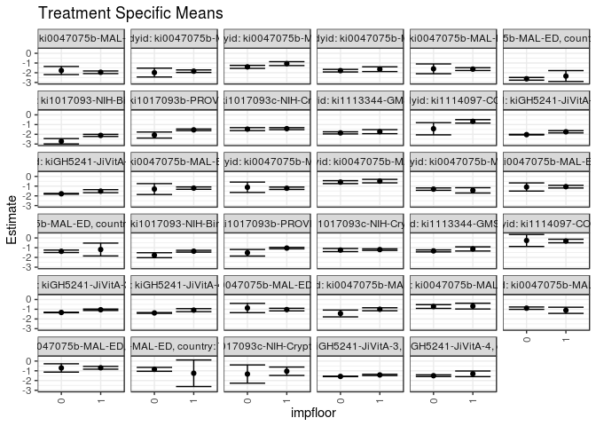

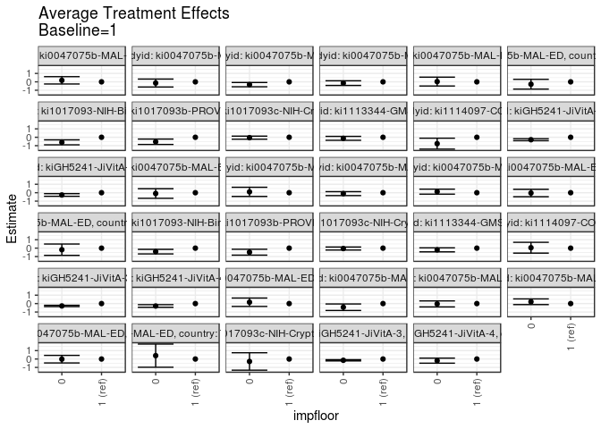

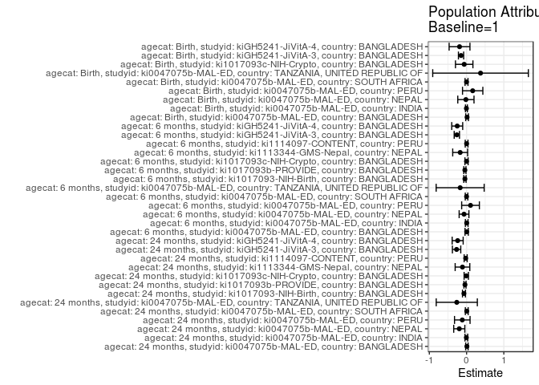

## Results Table

### Parameter: TSM

| agecat | studyid | country | intervention_level | baseline_level | estimate | ci_lower | ci_upper |
| --- | --- | --- | --- | --- | --- | --- | --- |
| Birth | ki0047075b-MAL-ED | BANGLADESH | 1 | NA | -1.0363610 | -1.1695847 | -0.9031373 |
| Birth | ki0047075b-MAL-ED | BANGLADESH | 0 | NA | -0.8745301 | -1.3532242 | -0.3958360 |
| Birth | ki0047075b-MAL-ED | INDIA | 1 | NA | -1.0023961 | -1.1538050 | -0.8509871 |
| Birth | ki0047075b-MAL-ED | INDIA | 0 | NA | -1.4340348 | -1.7854219 | -1.0826476 |
| Birth | ki0047075b-MAL-ED | NEPAL | 1 | NA | -0.6801693 | -0.9770805 | -0.3832580 |
| Birth | ki0047075b-MAL-ED | NEPAL | 0 | NA | -0.7211169 | -0.9133981 | -0.5288357 |
| Birth | ki0047075b-MAL-ED | PERU | 1 | NA | -1.1084469 | -1.4248725 | -0.7920213 |
| Birth | ki0047075b-MAL-ED | PERU | 0 | NA | -0.8909300 | -1.0119694 | -0.7698906 |
| Birth | ki0047075b-MAL-ED | SOUTH AFRICA | 1 | NA | -0.6899052 | -0.8313300 | -0.5484804 |
| Birth | ki0047075b-MAL-ED | SOUTH AFRICA | 0 | NA | -0.7062968 | -1.1331052 | -0.2794884 |
| Birth | ki0047075b-MAL-ED | TANZANIA, UNITED REPUBLIC OF | 1 | NA | -1.2525000 | -2.6166240 | 0.1116240 |
| Birth | ki0047075b-MAL-ED | TANZANIA, UNITED REPUBLIC OF | 0 | NA | -0.8502752 | -1.0483341 | -0.6522163 |
| Birth | ki1017093c-NIH-Crypto | BANGLADESH | 1 | NA | -1.0457143 | -1.4785067 | -0.6129219 |
| Birth | ki1017093c-NIH-Crypto | BANGLADESH | 0 | NA | -1.3350000 | -2.2736100 | -0.3963900 |
| Birth | kiGH5241-JiVitA-3 | BANGLADESH | 1 | NA | -1.4259716 | -1.4971170 | -1.3548263 |
| Birth | kiGH5241-JiVitA-3 | BANGLADESH | 0 | NA | -1.5773516 | -1.5975331 | -1.5571701 |
| Birth | kiGH5241-JiVitA-4 | BANGLADESH | 1 | NA | -1.3084019 | -1.5970111 | -1.0197928 |
| Birth | kiGH5241-JiVitA-4 | BANGLADESH | 0 | NA | -1.5032087 | -1.5914632 | -1.4149542 |
| 6 months | ki0047075b-MAL-ED | BANGLADESH | 1 | NA | -1.2054768 | -1.3246994 | -1.0862543 |
| 6 months | ki0047075b-MAL-ED | BANGLADESH | 0 | NA | -1.3019493 | -1.8616559 | -0.7422427 |
| 6 months | ki0047075b-MAL-ED | INDIA | 1 | NA | -1.2193536 | -1.3408113 | -1.0978959 |
| 6 months | ki0047075b-MAL-ED | INDIA | 0 | NA | -1.1180578 | -1.6500616 | -0.5860541 |
| 6 months | ki0047075b-MAL-ED | NEPAL | 1 | NA | -0.4846164 | -0.6632615 | -0.3059712 |
| 6 months | ki0047075b-MAL-ED | NEPAL | 0 | NA | -0.5906914 | -0.7397672 | -0.4416155 |
| 6 months | ki0047075b-MAL-ED | PERU | 1 | NA | -1.4337856 | -1.7054911 | -1.1620801 |
| 6 months | ki0047075b-MAL-ED | PERU | 0 | NA | -1.3078800 | -1.4281952 | -1.1875647 |
| 6 months | ki0047075b-MAL-ED | SOUTH AFRICA | 1 | NA | -1.0540645 | -1.1906790 | -0.9174500 |
| 6 months | ki0047075b-MAL-ED | SOUTH AFRICA | 0 | NA | -1.0905922 | -1.5102819 | -0.6709025 |
| 6 months | ki0047075b-MAL-ED | TANZANIA, UNITED REPUBLIC OF | 1 | NA | -1.1888924 | -1.8500990 | -0.5276857 |
| 6 months | ki0047075b-MAL-ED | TANZANIA, UNITED REPUBLIC OF | 0 | NA | -1.3746011 | -1.5011466 | -1.2480556 |
| 6 months | ki1017093-NIH-Birth | BANGLADESH | 1 | NA | -1.3613377 | -1.4549276 | -1.2677479 |
| 6 months | ki1017093-NIH-Birth | BANGLADESH | 0 | NA | -1.7746944 | -2.0293078 | -1.5200810 |
| 6 months | ki1017093b-PROVIDE | BANGLADESH | 1 | NA | -1.0408763 | -1.1176624 | -0.9640902 |
| 6 months | ki1017093b-PROVIDE | BANGLADESH | 0 | NA | -1.5235701 | -1.8628757 | -1.1842644 |
| 6 months | ki1017093c-NIH-Crypto | BANGLADESH | 1 | NA | -1.1970433 | -1.2783468 | -1.1157398 |
| 6 months | ki1017093c-NIH-Crypto | BANGLADESH | 0 | NA | -1.2439500 | -1.4044750 | -1.0834249 |
| 6 months | ki1113344-GMS-Nepal | NEPAL | 1 | NA | -1.1284174 | -1.3425904 | -0.9142444 |
| 6 months | ki1113344-GMS-Nepal | NEPAL | 0 | NA | -1.3308591 | -1.4328315 | -1.2288866 |
| 6 months | ki1114097-CONTENT | PERU | 1 | NA | -0.3143684 | -0.4957288 | -0.1330079 |
| 6 months | ki1114097-CONTENT | PERU | 0 | NA | -0.2609390 | -0.8773699 | 0.3554919 |
| 6 months | kiGH5241-JiVitA-3 | BANGLADESH | 1 | NA | -1.0515086 | -1.1234886 | -0.9795286 |
| 6 months | kiGH5241-JiVitA-3 | BANGLADESH | 0 | NA | -1.3313329 | -1.3550795 | -1.3075862 |
| 6 months | kiGH5241-JiVitA-4 | BANGLADESH | 1 | NA | -1.0924319 | -1.2481467 | -0.9367172 |
| 6 months | kiGH5241-JiVitA-4 | BANGLADESH | 0 | NA | -1.3810315 | -1.4206852 | -1.3413777 |
| 24 months | ki0047075b-MAL-ED | BANGLADESH | 1 | NA | -1.9516456 | -2.0845181 | -1.8187731 |
| 24 months | ki0047075b-MAL-ED | BANGLADESH | 0 | NA | -1.7719623 | -2.1869252 | -1.3569994 |
| 24 months | ki0047075b-MAL-ED | INDIA | 1 | NA | -1.8396210 | -1.9685578 | -1.7106842 |
| 24 months | ki0047075b-MAL-ED | INDIA | 0 | NA | -1.9829268 | -2.4368766 | -1.5289770 |
| 24 months | ki0047075b-MAL-ED | NEPAL | 1 | NA | -1.0655323 | -1.2661344 | -0.8649303 |
| 24 months | ki0047075b-MAL-ED | NEPAL | 0 | NA | -1.3975804 | -1.5513038 | -1.2438570 |
| 24 months | ki0047075b-MAL-ED | PERU | 1 | NA | -1.6344852 | -1.8785898 | -1.3903807 |
| 24 months | ki0047075b-MAL-ED | PERU | 0 | NA | -1.7851966 | -1.9186549 | -1.6517384 |
| 24 months | ki0047075b-MAL-ED | SOUTH AFRICA | 1 | NA | -1.6273496 | -1.7687286 | -1.4859706 |
| 24 months | ki0047075b-MAL-ED | SOUTH AFRICA | 0 | NA | -1.5962531 | -2.0995703 | -1.0929359 |
| 24 months | ki0047075b-MAL-ED | TANZANIA, UNITED REPUBLIC OF | 1 | NA | -2.3397018 | -2.9012142 | -1.7781893 |
| 24 months | ki0047075b-MAL-ED | TANZANIA, UNITED REPUBLIC OF | 0 | NA | -2.6225965 | -2.7627312 | -2.4824618 |
| 24 months | ki1017093-NIH-Birth | BANGLADESH | 1 | NA | -2.1145979 | -2.2224915 | -2.0067043 |
| 24 months | ki1017093-NIH-Birth | BANGLADESH | 0 | NA | -2.7151330 | -2.9908480 | -2.4394181 |
| 24 months | ki1017093b-PROVIDE | BANGLADESH | 1 | NA | -1.5424962 | -1.6275958 | -1.4573967 |
| 24 months | ki1017093b-PROVIDE | BANGLADESH | 0 | NA | -2.0765069 | -2.3871416 | -1.7658722 |
| 24 months | ki1017093c-NIH-Crypto | BANGLADESH | 1 | NA | -1.4209884 | -1.5230194 | -1.3189574 |
| 24 months | ki1017093c-NIH-Crypto | BANGLADESH | 0 | NA | -1.4683186 | -1.6202232 | -1.3164139 |
| 24 months | ki1113344-GMS-Nepal | NEPAL | 1 | NA | -1.7281516 | -1.9349997 | -1.5213035 |
| 24 months | ki1113344-GMS-Nepal | NEPAL | 0 | NA | -1.8538280 | -1.9614953 | -1.7461606 |
| 24 months | ki1114097-CONTENT | PERU | 1 | NA | -0.6712639 | -0.8487685 | -0.4937593 |
| 24 months | ki1114097-CONTENT | PERU | 0 | NA | -1.4304698 | -2.0558434 | -0.8050962 |
| 24 months | kiGH5241-JiVitA-3 | BANGLADESH | 1 | NA | -1.7436861 | -1.8568716 | -1.6305006 |
| 24 months | kiGH5241-JiVitA-3 | BANGLADESH | 0 | NA | -2.0337983 | -2.0624832 | -2.0051134 |
| 24 months | kiGH5241-JiVitA-4 | BANGLADESH | 1 | NA | -1.5182618 | -1.6732278 | -1.3632958 |
| 24 months | kiGH5241-JiVitA-4 | BANGLADESH | 0 | NA | -1.7868490 | -1.8242966 | -1.7494014 |

### Parameter: E(Y)

| agecat | studyid | country | intervention_level | baseline_level | estimate | ci_lower | ci_upper |
| --- | --- | --- | --- | --- | --- | --- | --- |
| Birth | ki0047075b-MAL-ED | BANGLADESH | NA | NA | -1.0229487 | -1.1509575 | -0.8949400 |
| Birth | ki0047075b-MAL-ED | INDIA | NA | NA | -1.0069634 | -1.1525107 | -0.8614160 |
| Birth | ki0047075b-MAL-ED | NEPAL | NA | NA | -0.6988415 | -0.8600838 | -0.5375991 |
| Birth | ki0047075b-MAL-ED | PERU | NA | NA | -0.9447876 | -1.0604945 | -0.8290808 |
| Birth | ki0047075b-MAL-ED | SOUTH AFRICA | NA | NA | -0.6917890 | -0.8248091 | -0.5587689 |
| Birth | ki0047075b-MAL-ED | TANZANIA, UNITED REPUBLIC OF | NA | NA | -0.8777778 | -1.0853531 | -0.6702024 |
| Birth | ki1017093c-NIH-Crypto | BANGLADESH | NA | NA | -1.1100000 | -1.5086894 | -0.7113106 |
| Birth | kiGH5241-JiVitA-3 | BANGLADESH | NA | NA | -1.5749762 | -1.5947643 | -1.5551882 |
| Birth | kiGH5241-JiVitA-4 | BANGLADESH | NA | NA | -1.4976642 | -1.5817349 | -1.4135935 |
| 6 months | ki0047075b-MAL-ED | BANGLADESH | NA | NA | -1.2033681 | -1.3212429 | -1.0854932 |
| 6 months | ki0047075b-MAL-ED | INDIA | NA | NA | -1.2159433 | -1.3345235 | -1.0973630 |
| 6 months | ki0047075b-MAL-ED | NEPAL | NA | NA | -0.5534934 | -0.6683107 | -0.4386762 |
| 6 months | ki0047075b-MAL-ED | PERU | NA | NA | -1.3280247 | -1.4371552 | -1.2188942 |
| 6 months | ki0047075b-MAL-ED | SOUTH AFRICA | NA | NA | -1.0548494 | -1.1845497 | -0.9251491 |
| 6 months | ki0047075b-MAL-ED | TANZANIA, UNITED REPUBLIC OF | NA | NA | -1.3613469 | -1.4843950 | -1.2382988 |
| 6 months | ki1017093-NIH-Birth | BANGLADESH | NA | NA | -1.4060639 | -1.4948910 | -1.3172368 |
| 6 months | ki1017093b-PROVIDE | BANGLADESH | NA | NA | -1.0871041 | -1.1635539 | -1.0106543 |
| 6 months | ki1017093c-NIH-Crypto | BANGLADESH | NA | NA | -1.1986783 | -1.2700937 | -1.1272630 |
| 6 months | ki1113344-GMS-Nepal | NEPAL | NA | NA | -1.3005896 | -1.3898487 | -1.2113304 |
| 6 months | ki1114097-CONTENT | PERU | NA | NA | -0.3139217 | -0.4868486 | -0.1409948 |
| 6 months | kiGH5241-JiVitA-3 | BANGLADESH | NA | NA | -1.3134597 | -1.3365976 | -1.2903219 |
| 6 months | kiGH5241-JiVitA-4 | BANGLADESH | NA | NA | -1.3440174 | -1.3812821 | -1.3067527 |
| 24 months | ki0047075b-MAL-ED | BANGLADESH | NA | NA | -1.9431132 | -2.0691678 | -1.8170586 |
| 24 months | ki0047075b-MAL-ED | INDIA | NA | NA | -1.8458150 | -1.9718703 | -1.7197596 |
| 24 months | ki0047075b-MAL-ED | NEPAL | NA | NA | -1.2618778 | -1.3846215 | -1.1391341 |
| 24 months | ki0047075b-MAL-ED | PERU | NA | NA | -1.7500995 | -1.8705474 | -1.6296516 |
| 24 months | ki0047075b-MAL-ED | SOUTH AFRICA | NA | NA | -1.6228361 | -1.7581177 | -1.4875546 |
| 24 months | ki0047075b-MAL-ED | TANZANIA, UNITED REPUBLIC OF | NA | NA | -2.6031840 | -2.7387629 | -2.4676050 |
| 24 months | ki1017093-NIH-Birth | BANGLADESH | NA | NA | -2.1856460 | -2.2886758 | -2.0826161 |
| 24 months | ki1017093b-PROVIDE | BANGLADESH | NA | NA | -1.5861179 | -1.6693668 | -1.5028689 |
| 24 months | ki1017093c-NIH-Crypto | BANGLADESH | NA | NA | -1.4295331 | -1.5127726 | -1.3462935 |
| 24 months | ki1113344-GMS-Nepal | NEPAL | NA | NA | -1.8384978 | -1.9325778 | -1.7444179 |
| 24 months | ki1114097-CONTENT | PERU | NA | NA | -0.6962195 | -0.8674103 | -0.5250287 |
| 24 months | kiGH5241-JiVitA-3 | BANGLADESH | NA | NA | -2.0124544 | -2.0401076 | -1.9848012 |
| 24 months | kiGH5241-JiVitA-4 | BANGLADESH | NA | NA | -1.7579225 | -1.7933649 | -1.7224800 |

### Parameter: ATE

| agecat | studyid | country | intervention_level | baseline_level | estimate | ci_lower | ci_upper |
| --- | --- | --- | --- | --- | --- | --- | --- |
| Birth | ki0047075b-MAL-ED | BANGLADESH | 1 | 1 | 0.0000000 | 0.0000000 | 0.0000000 |
| Birth | ki0047075b-MAL-ED | BANGLADESH | 0 | 1 | 0.1618309 | -0.3353540 | 0.6590158 |
| Birth | ki0047075b-MAL-ED | INDIA | 1 | 1 | 0.0000000 | 0.0000000 | 0.0000000 |
| Birth | ki0047075b-MAL-ED | INDIA | 0 | 1 | -0.4316387 | -0.8169967 | -0.0462807 |
| Birth | ki0047075b-MAL-ED | NEPAL | 1 | 1 | 0.0000000 | 0.0000000 | 0.0000000 |
| Birth | ki0047075b-MAL-ED | NEPAL | 0 | 1 | -0.0409476 | -0.3954819 | 0.3135867 |
| Birth | ki0047075b-MAL-ED | PERU | 1 | 1 | 0.0000000 | 0.0000000 | 0.0000000 |
| Birth | ki0047075b-MAL-ED | PERU | 0 | 1 | 0.2175169 | -0.1208714 | 0.5559051 |
| Birth | ki0047075b-MAL-ED | SOUTH AFRICA | 1 | 1 | 0.0000000 | 0.0000000 | 0.0000000 |
| Birth | ki0047075b-MAL-ED | SOUTH AFRICA | 0 | 1 | -0.0163916 | -0.4664916 | 0.4337083 |
| Birth | ki0047075b-MAL-ED | TANZANIA, UNITED REPUBLIC OF | 1 | 1 | 0.0000000 | 0.0000000 | 0.0000000 |
| Birth | ki0047075b-MAL-ED | TANZANIA, UNITED REPUBLIC OF | 0 | 1 | 0.4022248 | -0.9762024 | 1.7806520 |
| Birth | ki1017093c-NIH-Crypto | BANGLADESH | 1 | 1 | 0.0000000 | 0.0000000 | 0.0000000 |
| Birth | ki1017093c-NIH-Crypto | BANGLADESH | 0 | 1 | -0.2892857 | -1.3228707 | 0.7442993 |
| Birth | kiGH5241-JiVitA-3 | BANGLADESH | 1 | 1 | 0.0000000 | 0.0000000 | 0.0000000 |
| Birth | kiGH5241-JiVitA-3 | BANGLADESH | 0 | 1 | -0.1513800 | -0.2242830 | -0.0784770 |
| Birth | kiGH5241-JiVitA-4 | BANGLADESH | 1 | 1 | 0.0000000 | 0.0000000 | 0.0000000 |
| Birth | kiGH5241-JiVitA-4 | BANGLADESH | 0 | 1 | -0.1948068 | -0.4969705 | 0.1073570 |
| 6 months | ki0047075b-MAL-ED | BANGLADESH | 1 | 1 | 0.0000000 | 0.0000000 | 0.0000000 |
| 6 months | ki0047075b-MAL-ED | BANGLADESH | 0 | 1 | -0.0964724 | -0.6687817 | 0.4758368 |
| 6 months | ki0047075b-MAL-ED | INDIA | 1 | 1 | 0.0000000 | 0.0000000 | 0.0000000 |
| 6 months | ki0047075b-MAL-ED | INDIA | 0 | 1 | 0.1012958 | -0.4442930 | 0.6468845 |
| 6 months | ki0047075b-MAL-ED | NEPAL | 1 | 1 | 0.0000000 | 0.0000000 | 0.0000000 |
| 6 months | ki0047075b-MAL-ED | NEPAL | 0 | 1 | -0.1060750 | -0.3398101 | 0.1276601 |
| 6 months | ki0047075b-MAL-ED | PERU | 1 | 1 | 0.0000000 | 0.0000000 | 0.0000000 |
| 6 months | ki0047075b-MAL-ED | PERU | 0 | 1 | 0.1259057 | -0.1718699 | 0.4236813 |
| 6 months | ki0047075b-MAL-ED | SOUTH AFRICA | 1 | 1 | 0.0000000 | 0.0000000 | 0.0000000 |
| 6 months | ki0047075b-MAL-ED | SOUTH AFRICA | 0 | 1 | -0.0365277 | -0.4784129 | 0.4053574 |
| 6 months | ki0047075b-MAL-ED | TANZANIA, UNITED REPUBLIC OF | 1 | 1 | 0.0000000 | 0.0000000 | 0.0000000 |
| 6 months | ki0047075b-MAL-ED | TANZANIA, UNITED REPUBLIC OF | 0 | 1 | -0.1857087 | -0.8591431 | 0.4877257 |
| 6 months | ki1017093-NIH-Birth | BANGLADESH | 1 | 1 | 0.0000000 | 0.0000000 | 0.0000000 |
| 6 months | ki1017093-NIH-Birth | BANGLADESH | 0 | 1 | -0.4133567 | -0.6837435 | -0.1429699 |
| 6 months | ki1017093b-PROVIDE | BANGLADESH | 1 | 1 | 0.0000000 | 0.0000000 | 0.0000000 |
| 6 months | ki1017093b-PROVIDE | BANGLADESH | 0 | 1 | -0.4826937 | -0.8309667 | -0.1344207 |
| 6 months | ki1017093c-NIH-Crypto | BANGLADESH | 1 | 1 | 0.0000000 | 0.0000000 | 0.0000000 |
| 6 months | ki1017093c-NIH-Crypto | BANGLADESH | 0 | 1 | -0.0469066 | -0.2259393 | 0.1321260 |
| 6 months | ki1113344-GMS-Nepal | NEPAL | 1 | 1 | 0.0000000 | 0.0000000 | 0.0000000 |
| 6 months | ki1113344-GMS-Nepal | NEPAL | 0 | 1 | -0.2024417 | -0.4414142 | 0.0365309 |
| 6 months | ki1114097-CONTENT | PERU | 1 | 1 | 0.0000000 | 0.0000000 | 0.0000000 |
| 6 months | ki1114097-CONTENT | PERU | 0 | 1 | 0.0534294 | -0.5904727 | 0.6973314 |
| 6 months | kiGH5241-JiVitA-3 | BANGLADESH | 1 | 1 | 0.0000000 | 0.0000000 | 0.0000000 |
| 6 months | kiGH5241-JiVitA-3 | BANGLADESH | 0 | 1 | -0.2798243 | -0.3542561 | -0.2053925 |
| 6 months | kiGH5241-JiVitA-4 | BANGLADESH | 1 | 1 | 0.0000000 | 0.0000000 | 0.0000000 |
| 6 months | kiGH5241-JiVitA-4 | BANGLADESH | 0 | 1 | -0.2885996 | -0.4462132 | -0.1309860 |
| 24 months | ki0047075b-MAL-ED | BANGLADESH | 1 | 1 | 0.0000000 | 0.0000000 | 0.0000000 |
| 24 months | ki0047075b-MAL-ED | BANGLADESH | 0 | 1 | 0.1796833 | -0.2565273 | 0.6158940 |
| 24 months | ki0047075b-MAL-ED | INDIA | 1 | 1 | 0.0000000 | 0.0000000 | 0.0000000 |
| 24 months | ki0047075b-MAL-ED | INDIA | 0 | 1 | -0.1433058 | -0.6162606 | 0.3296490 |
| 24 months | ki0047075b-MAL-ED | NEPAL | 1 | 1 | 0.0000000 | 0.0000000 | 0.0000000 |
| 24 months | ki0047075b-MAL-ED | NEPAL | 0 | 1 | -0.3320481 | -0.5863620 | -0.0777342 |
| 24 months | ki0047075b-MAL-ED | PERU | 1 | 1 | 0.0000000 | 0.0000000 | 0.0000000 |
| 24 months | ki0047075b-MAL-ED | PERU | 0 | 1 | -0.1507114 | -0.4280318 | 0.1266090 |
| 24 months | ki0047075b-MAL-ED | SOUTH AFRICA | 1 | 1 | 0.0000000 | 0.0000000 | 0.0000000 |
| 24 months | ki0047075b-MAL-ED | SOUTH AFRICA | 0 | 1 | 0.0310965 | -0.4929276 | 0.5551206 |
| 24 months | ki0047075b-MAL-ED | TANZANIA, UNITED REPUBLIC OF | 1 | 1 | 0.0000000 | 0.0000000 | 0.0000000 |
| 24 months | ki0047075b-MAL-ED | TANZANIA, UNITED REPUBLIC OF | 0 | 1 | -0.2828947 | -0.8621612 | 0.2963717 |
| 24 months | ki1017093-NIH-Birth | BANGLADESH | 1 | 1 | 0.0000000 | 0.0000000 | 0.0000000 |
| 24 months | ki1017093-NIH-Birth | BANGLADESH | 0 | 1 | -0.6005351 | -0.8952471 | -0.3058231 |
| 24 months | ki1017093b-PROVIDE | BANGLADESH | 1 | 1 | 0.0000000 | 0.0000000 | 0.0000000 |
| 24 months | ki1017093b-PROVIDE | BANGLADESH | 0 | 1 | -0.5340106 | -0.8553723 | -0.2126489 |
| 24 months | ki1017093c-NIH-Crypto | BANGLADESH | 1 | 1 | 0.0000000 | 0.0000000 | 0.0000000 |
| 24 months | ki1017093c-NIH-Crypto | BANGLADESH | 0 | 1 | -0.0473302 | -0.2299900 | 0.1353297 |
| 24 months | ki1113344-GMS-Nepal | NEPAL | 1 | 1 | 0.0000000 | 0.0000000 | 0.0000000 |
| 24 months | ki1113344-GMS-Nepal | NEPAL | 0 | 1 | -0.1256764 | -0.3586866 | 0.1073339 |
| 24 months | ki1114097-CONTENT | PERU | 1 | 1 | 0.0000000 | 0.0000000 | 0.0000000 |
| 24 months | ki1114097-CONTENT | PERU | 0 | 1 | -0.7592058 | -1.4097348 | -0.1086768 |
| 24 months | kiGH5241-JiVitA-3 | BANGLADESH | 1 | 1 | 0.0000000 | 0.0000000 | 0.0000000 |
| 24 months | kiGH5241-JiVitA-3 | BANGLADESH | 0 | 1 | -0.2901122 | -0.4066463 | -0.1735781 |
| 24 months | kiGH5241-JiVitA-4 | BANGLADESH | 1 | 1 | 0.0000000 | 0.0000000 | 0.0000000 |
| 24 months | kiGH5241-JiVitA-4 | BANGLADESH | 0 | 1 | -0.2685872 | -0.4262125 | -0.1109620 |

### Parameter: PAR

| agecat | studyid | country | intervention_level | baseline_level | estimate | ci_lower | ci_upper |
| --- | --- | --- | --- | --- | --- | --- | --- |
| Birth | ki0047075b-MAL-ED | BANGLADESH | 1 | NA | 0.0134123 | -0.0237762 | 0.0506008 |
| Birth | ki0047075b-MAL-ED | INDIA | 1 | NA | -0.0045673 | -0.0305451 | 0.0214106 |
| Birth | ki0047075b-MAL-ED | NEPAL | 1 | NA | -0.0186722 | -0.2366302 | 0.1992858 |
| Birth | ki0047075b-MAL-ED | PERU | 1 | NA | 0.1636592 | -0.1093315 | 0.4366500 |
| Birth | ki0047075b-MAL-ED | SOUTH AFRICA | 1 | NA | -0.0018838 | -0.0414443 | 0.0376767 |
| Birth | ki0047075b-MAL-ED | TANZANIA, UNITED REPUBLIC OF | 1 | NA | 0.3747222 | -0.9095864 | 1.6590309 |
| Birth | ki1017093c-NIH-Crypto | BANGLADESH | 1 | NA | -0.0642857 | -0.2985773 | 0.1700058 |
| Birth | kiGH5241-JiVitA-3 | BANGLADESH | 1 | NA | -0.1490046 | -0.2191125 | -0.0788967 |
| Birth | kiGH5241-JiVitA-4 | BANGLADESH | 1 | NA | -0.1892623 | -0.4686008 | 0.0900762 |
| 6 months | ki0047075b-MAL-ED | BANGLADESH | 1 | NA | 0.0021088 | -0.0420800 | 0.0462975 |
| 6 months | ki0047075b-MAL-ED | INDIA | 1 | NA | 0.0034104 | -0.0326667 | 0.0394875 |
| 6 months | ki0047075b-MAL-ED | NEPAL | 1 | NA | -0.0688771 | -0.1996406 | 0.0618864 |
| 6 months | ki0047075b-MAL-ED | PERU | 1 | NA | 0.1057609 | -0.1319544 | 0.3434763 |
| 6 months | ki0047075b-MAL-ED | SOUTH AFRICA | 1 | NA | -0.0007849 | -0.0355177 | 0.0339479 |
| 6 months | ki0047075b-MAL-ED | TANZANIA, UNITED REPUBLIC OF | 1 | NA | -0.1724546 | -0.8171566 | 0.4722474 |
| 6 months | ki1017093-NIH-Birth | BANGLADESH | 1 | NA | -0.0447261 | -0.0751850 | -0.0142673 |
| 6 months | ki1017093b-PROVIDE | BANGLADESH | 1 | NA | -0.0462277 | -0.0753728 | -0.0170826 |
| 6 months | ki1017093c-NIH-Crypto | BANGLADESH | 1 | NA | -0.0016350 | -0.0444458 | 0.0411759 |
| 6 months | ki1113344-GMS-Nepal | NEPAL | 1 | NA | -0.1721722 | -0.3726637 | 0.0283194 |
| 6 months | ki1114097-CONTENT | PERU | 1 | NA | 0.0004467 | -0.0363064 | 0.0371997 |
| 6 months | kiGH5241-JiVitA-3 | BANGLADESH | 1 | NA | -0.2619511 | -0.3330276 | -0.1908746 |
| 6 months | kiGH5241-JiVitA-4 | BANGLADESH | 1 | NA | -0.2515855 | -0.3986567 | -0.1045142 |
| 24 months | ki0047075b-MAL-ED | BANGLADESH | 1 | NA | 0.0085324 | -0.0245590 | 0.0416238 |
| 24 months | ki0047075b-MAL-ED | INDIA | 1 | NA | -0.0061940 | -0.0427368 | 0.0303489 |
| 24 months | ki0047075b-MAL-ED | NEPAL | 1 | NA | -0.1963455 | -0.3457295 | -0.0469615 |
| 24 months | ki0047075b-MAL-ED | PERU | 1 | NA | -0.1156143 | -0.3241645 | 0.0929359 |
| 24 months | ki0047075b-MAL-ED | SOUTH AFRICA | 1 | NA | 0.0045135 | -0.0337679 | 0.0427948 |
| 24 months | ki0047075b-MAL-ED | TANZANIA, UNITED REPUBLIC OF | 1 | NA | -0.2634822 | -0.8155864 | 0.2886220 |
| 24 months | ki1017093-NIH-Birth | BANGLADESH | 1 | NA | -0.0710481 | -0.1101999 | -0.0318963 |
| 24 months | ki1017093b-PROVIDE | BANGLADESH | 1 | NA | -0.0436216 | -0.0712573 | -0.0159860 |
| 24 months | ki1017093c-NIH-Crypto | BANGLADESH | 1 | NA | -0.0085447 | -0.0667186 | 0.0496292 |
| 24 months | ki1113344-GMS-Nepal | NEPAL | 1 | NA | -0.1103462 | -0.3068710 | 0.0861786 |
| 24 months | ki1114097-CONTENT | PERU | 1 | NA | -0.0249556 | -0.0654897 | 0.0155785 |
| 24 months | kiGH5241-JiVitA-3 | BANGLADESH | 1 | NA | -0.2687683 | -0.3809487 | -0.1565879 |
| 24 months | kiGH5241-JiVitA-4 | BANGLADESH | 1 | NA | -0.2396607 | -0.3874950 | -0.0918263 |